# Phylogenetic Independent Contrasts in R

Casey W. Dunn

## Introduction

This document introduces you to a variety of tools and approaches to analyzing phylogenetic data with R.

There is detailed information on phylogenetic analysis with R at both [the R phylo wiki](http://www.r-phylo.org/wiki/Main_Page) and the [CRAN task page for phylogenetics](http://cran.r-project.org/web/views/Phylogenetics.html). Also consult the excellent book by Paradis (2012).

Make sure that you have the most recent version of R installed. For the analyses below, you will need to install the following libraries in R:

- ape
- geiger
- phylobase
- adephylo

Update them if they are not the latest version.

## Simulations

### Simulating trees

First, load ape:

```r
library(ape)
set.seed(4984356)
```

The simplest way to generate a random tree is with the rcoal() function:

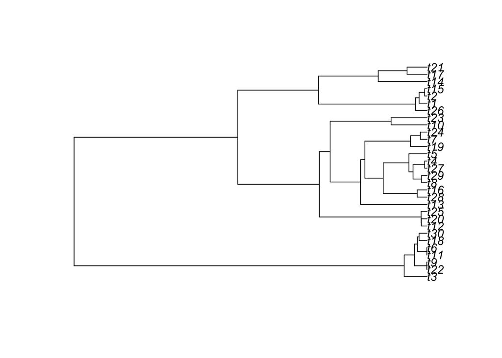

```r
t <- rcoal( 30 )
plot( t )
```

The only required argument is the number of taxa. rcoal() generates ultrametric trees, the related function rtree() can be used to generate trees whose tips are not contemporaneous.

### Simulating phenotypic data on trees

The `sim.char()` function from the geiger library is a convenient tool for simulating character evolution.

We’ll simulate three characters, each with a variance of 1. The fist two characters will have a covariance of 0.7 with each other. The third characters will have a covariance of 0 with the other characters. First, make a variance-covariance matrix describes this relationship:

```r
vcv <- diag( 3 )
vcv[1,2] <- 0.7
vcv[2,1] <- 0.7
vcv
```

```
##      [,1] [,2] [,3]
## [1,]  1.0  0.7    0
## [2,]  0.7  1.0    0
## [3,]  0.0  0.0    1
```

Now, generate multiple simulated datasets on tree t according to vcv:

```r
library(geiger)
D <- sim.char( t, vcv, nsim = 100, model = "BM", root = 0 )
D[,,1]
```

```
##            [,1]         [,2]        [,3]
## t3  -0.25687264 -0.853011008  0.82282071
## t22  0.20647462 -0.246432243  0.23108355
## t9   0.24536792 -0.234023235  0.22878401
## t11 -0.34538261 -0.608467771  0.15115641
## t6  -0.25286636 -0.599591215  0.14472770
## t18  0.10159487  0.008807298  0.54257224
## t30 -0.12959588 -0.361382407  0.24504345
## t12  0.52090566  1.096020557 -0.68348458
## t20  0.04187948  0.647013252 -0.59663292
## t25  0.18103201  0.902720760 -0.92643672
## t13 -0.08255119  1.071612012 -0.75585909
## t28 -0.94849786  0.545381617 -0.44884319
## t16 -1.07693946  0.368337800 -0.64485772
## t8  -0.90036260  0.782241930 -0.53362991
## t29 -1.18947100  0.674672036 -0.47136873
## t27 -0.72318304  0.924485377 -0.56036679
## t4  -0.82090696  0.819943995 -0.46790169
## t5  -1.58203549  0.338525682 -0.37750191
## t19 -0.80292242  0.484220719  0.04921869
## t7  -0.64581799  0.575314720 -0.02252698
## t24 -1.05335315  0.358515448 -0.23464249
## t10 -0.72648314  1.184412064 -0.85453726
## t23 -0.47778608  1.240891766  0.04424223
## t26  0.91982739  1.061574005  0.03749574
## t1   0.72174660  0.814439871 -0.02706619
## t2   0.64167064  1.147186957  0.20505346
## t15  0.85307386  1.220943053  0.13258912
## t14  1.05038568  2.306117334 -0.17045876
## t17  0.52393644  2.008669543 -0.33153804
## t21  0.71291432  1.547256090 -0.70087490
```

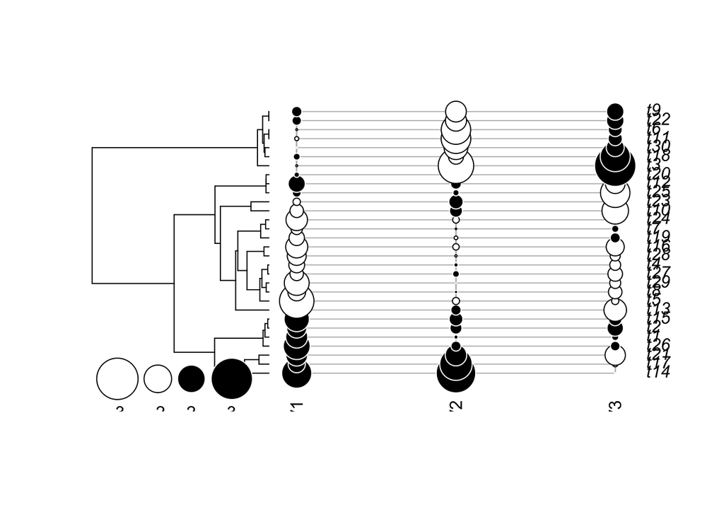

```r
library( adephylo )
library( phylobase )
D4 <- phylo4d( t, D[,,1] )
table.phylo4d( D4, box=FALSE )
```

Now construct independent contrasts for each of the three variables:

```r
ic1 <- pic( D[,1,1], t )
ic2 <- pic( D[,2,1], t )
ic3 <- pic( D[,3,1], t )

cov( cbind( ic1, ic2, ic3 ) )
```

```
##             ic1        ic2         ic3
## ic1  1.39927789 0.82853694 -0.01678223
## ic2  0.82853694 1.06611608  0.05713996
## ic3 -0.01678223 0.05713996  0.67307269
```

This matrix is based on a single simulation, and will differ by chance from the original vcv matrix that we defined above.

Compare the result to what we get when we look at covariance of the values at the tips, rather than the independent contrasts:

```r
cov( cbind( D[,1,1], D[,2,1], D[,3,1] ) )
```

```
##            [,1]       [,2]        [,3]
## [1,] 0.51938406  0.1936781  0.07115525
## [2,] 0.19367814  0.5547315 -0.17359385
## [3,] 0.07115525 -0.1735938  0.19055367
```

## Phylogenetic signal

Many studies use `K` (Blomberg 2003) to assess the “phylogenetic signal” of a character. Under a Brownian motion model on a phylogenetic tree, a `K` of 1 is expected. For `K<1`, relatives resemble each other less than expected. For `K>1`, relatives resemble each other more than expected.

This measure has been implemented in the picante library.

```r
library(picante)
Kcalc( D[,1,1], t )
```

```
##           [,1]
## [1,] 0.5366881
```

Now take a look at `K` for a variable that has been simulated without consideration of the tree:

```r
ntips <- length( t$tip.label )
x <- rnorm( ntips, mean=0, sd=1 )
names(x) <- names( D[,1,1] )
Kcalc( x, t )
```

```
##            [,1]
## [1,] 0.00961478
```

Neither of these values are exactly 1, but it is not clear if the difference is significant. This can be addressed via randomization tests as implemented by the phylosignal() function

```r
phylosignal( D[,1,1], t )
```

```
##           K PIC.variance.obs PIC.variance.rnd.mean PIC.variance.P
## 1 0.5366881         1.442863              54.13598          0.001
##   PIC.variance.Z
## 1      -1.603201
```

```r
phylosignal( x, t )
```

```
##            K PIC.variance.obs PIC.variance.rnd.mean PIC.variance.P
## 1 0.00961478         134.0673                98.611          0.771
##   PIC.variance.Z
## 1      0.4937875
```

## How this document was made

This document is a computable data report compiled directly from the data. To recreate this file from the data, you can open it in RStudio and click the “knit” button.

## References

Blomberg, S. P., T. Garland, and A. R. Ives. 2003. Testing for phylogenetic signal in comparative data: behavioral traits are more labile. Evolution 57:717–745.

Paradis, E. 2012. Analysis of Phylogenetics and Evolution With R. Springer Science+Business Media.